# Radiological gastrostomy - patient demography

Martin Hennessy

2024-02-22

- Included are data about gastrostomies performed on 1017 patients between 2014-01-06 and 2023-12-21
- Repeat gastrostomies are counted only if the new gastrostomy required a new gastric puncture
- Re-canalisation of existing tracts with a wire are not included

## Gastrostomy demography

- The table below summarises the sex and age of gastrostomy patients:

| Diagnosis | Patients | Procedures | Men | Women | Mean age (years) | SD | Median age (years) | IQR |
| --- | --- | --- | --- | --- | --- | --- | --- | --- |
| All | 1,017 | 1,064 | 662 | 355 | 64 | 14 | 65 | 57 - 73 |
| ENT | 517 | 542 | 359 | 158 | 64 | 10 | 65 | 58 - 71 |
| MND | 147 | 152 | 85 | 62 | 64 | 11 | 65 | 57 - 72 |
| CVA | 111 | 115 | 57 | 54 | 73 | 14 | 76 | 67 - 84 |
| INJ | 60 | 67 | 48 | 12 | 58 | 16 | 57 | 48 - 70 |
| NEU | 69 | 70 | 48 | 21 | 56 | 20 | 61 | 42 - 72 |
| UNK | 69 | 70 | 41 | 28 | 56 | 23 | 62 | 36 - 73 |
| OES | 44 | 48 | 24 | 20 | 68 | 10 | 68 | 60 - 76 |

## Age

- In terms of age, the appropriate location and spread of data depends on whether or not it is normally distributed.
- For each diagnosis, this can be visualised by histograms, as below:

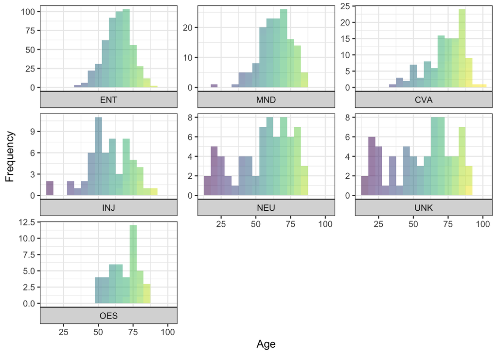

```
## ENT: p = 0.0680879700362813
## MND: p = 0.0080172440177187
## CVA: p = 9.27965294005948e-05
## INJ: p = 0.338743279118187
## NEU: p = 0.000734527879023378
## UNK: p = 0.000866734686025488
## OES: p = 0.137136558232124
```

- Mean and standard deviation are appropriate where *p*>0.05, median and interquartile range when the opposite is true.
- Finally, an idea of the location and spread of the ages as well as the number of patients for each diagnosis can be visualised in a point plot, where each point represents a single patient:

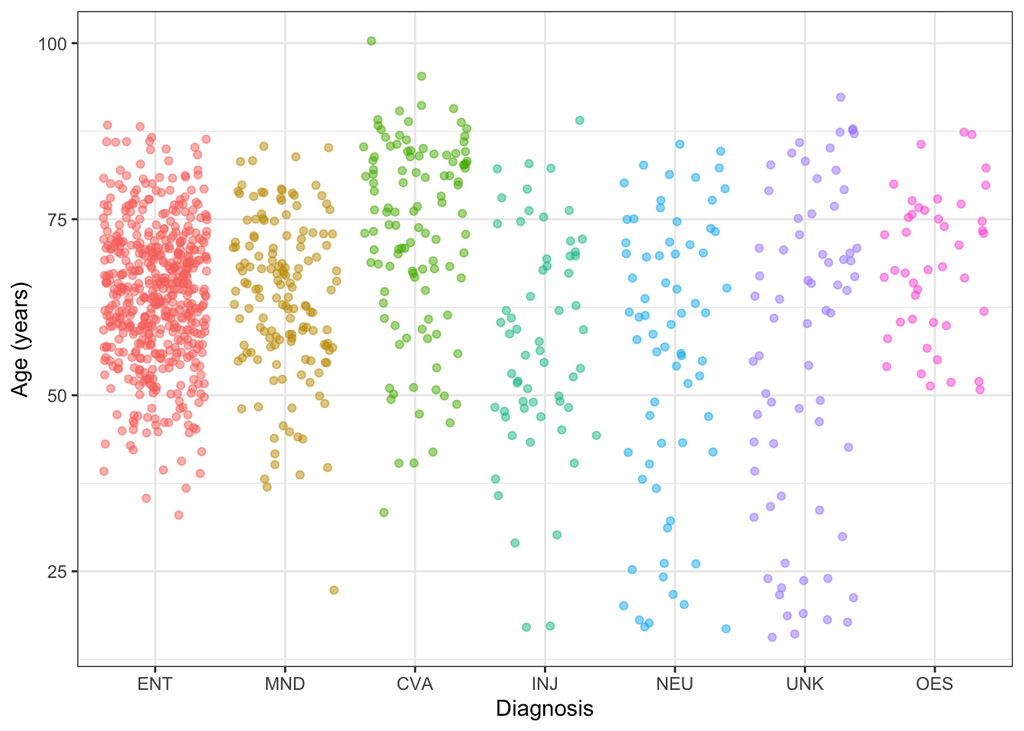

- Note, random jitter has been applied to decrease overlap of points on the chart.

## Sex

- The number of men and women for each diagnosis can also be visualised:

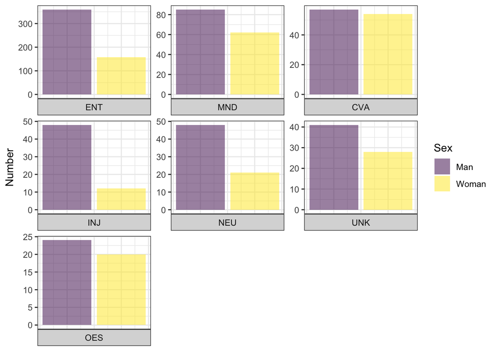

Abbreviations used above are as follows:

- ENT: ear, nose and throat cancers and their management
- MND: motor neurone disease
- CVA: stroke
- OES: oesophageal disease
- NEU: other neurodegenerative diseases
- INJ: traumatic brain and spine injuries
- UNK: the remaining miscellaneous or un-diagnosed conditions